# Machine Learning Coursera CourseProject

Michele martin

8 juin 2016

Using devices such as Jawbone Up, Nike FuelBand, and Fitbit it is now possible to collect a large amount of data about personal activity relatively inexpensively. These type of devices are part of the quantified self movement - a group of enthusiasts who take measurements about themselves regularly to improve their health, to find patterns in their behavior, or because they are tech geeks. One thing that people regularly do is quantify how much of a particular activity they do, but they rarely quantify how well they do it. In this project, your goal will be to use data from accelerometers on the belt, forearm, arm, and dumbell of 6 participants. They were asked to perform barbell lifts correctly and incorrectly in 5 different ways. More information is available from the website here: http://groupware.les.inf.puc-rio.br/har (see the section on the Weight Lifting Exercise Dataset).

**Load and prepare DATA and build 1st Model : RF with pre-processing PCA**

Read data and get rid of columns containing NA + 7 first ones (timestamp, users, etc) that are useless for our exercise.

```r
training<-read.csv("pml-training.csv",sep=",",header=TRUE,na.strings = c("", "NA"))
testing<-read.csv("pml-testing.csv",sep=",",header=TRUE,na.strings = c("", "NA"))
i<-1:160
usecol<-function(x){sum(is.na(x))}
usec<-sapply(testing[,i],usecol)
usec<-usec[usec == 0] #variables with NA values in testing are removed to avoid to build model on them with the training data
#classe variable is replaced by problem_id in testing
usec<-usec[names(usec)%in%names(training)]
training <- training[,c(names(usec),"classe")]
testing <- testing[,c(names(usec),"problem_id")]
training<-training[,-c(1:7)]
testing<-testing[,-c(1:7)]
```

Subset data from training data to build and choose model

```r
set.seed(100262)
library(caret)
library(randomForest)
inTrain = createDataPartition(training$classe, p = 0.6, list = FALSE)
training = training[inTrain,]
newtesting = training[-inTrain,]
```

Let’s see if the number of variables could be reduced

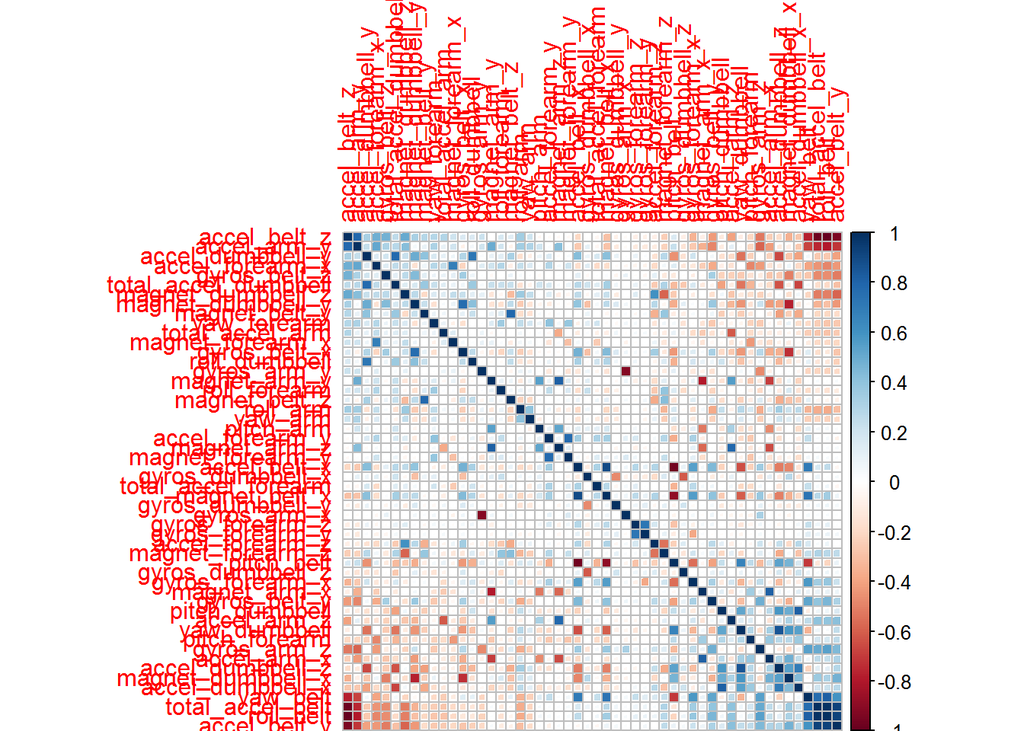

```r
cortable<- cor(training[, -53])
library(corrplot)
corrplot(cortable, order = "FPC", method = "square")
```

```r
prep<-preProcess(x=training[,-53],method="pca",thresh=0.8,na.remove=TRUE)#construct PCA model-new variables
trainingpca<-predict(object=prep,newdata= training[,-53]) #calculate the new values for the new variables in training
testingpca<-predict(object=prep,newdata= newtesting[,-53]) #idem for testing
modelpcarf<-randomForest(training$classe~.,trainingpca)
fitpcarf<-predict(modelpcarf,testingpca,type="class")
modelpcarf
```

```
##
## Call:
##  randomForest(formula = training$classe ~ ., data = trainingpca)
##                Type of random forest: classification
##                      Number of trees: 500
## No. of variables tried at each split: 3
##
##         OOB estimate of  error rate: 4.45%
## Confusion matrix:
##      A    B    C    D    E class.error
## A 3258   24   35   25    6  0.02688172
## B   54 2162   55    2    6  0.05133831
## C   25   39 1953   29    8  0.04917235
## D   19   11   96 1795    9  0.06994819
## E    7   26   25   23 2084  0.03741339
```

```r
confusionMatrix(reference=newtesting$classe,data=fitpcarf)#test accuracy on testingdata with new var
```

```
## Confusion Matrix and Statistics
##
##           Reference
## Prediction    A    B    C    D    E
##          A 1358    0    0    0    0
##          B    0  887    0    0    0
##          C    0    0  820    0    0
##          D    0    0    0  773    0
##          E    0    0    0    0  845
##
## Overall Statistics
##
##                Accuracy : 1
##                  95% CI : (0.9992, 1)
##     No Information Rate : 0.29
##     P-Value [Acc > NIR] : < 2.2e-16
##
##                   Kappa : 1
##  Mcnemar's Test P-Value : NA
##
## Statistics by Class:
##
##                      Class: A Class: B Class: C Class: D Class: E
## Sensitivity              1.00   1.0000   1.0000   1.0000   1.0000
## Specificity              1.00   1.0000   1.0000   1.0000   1.0000
## Pos Pred Value           1.00   1.0000   1.0000   1.0000   1.0000
## Neg Pred Value           1.00   1.0000   1.0000   1.0000   1.0000
## Prevalence               0.29   0.1894   0.1751   0.1651   0.1804
## Detection Rate           0.29   0.1894   0.1751   0.1651   0.1804
## Detection Prevalence     0.29   0.1894   0.1751   0.1651   0.1804
## Balanced Accuracy        1.00   1.0000   1.0000   1.0000   1.0000
```

**Compare briefly with other models**

Let’s try an lda model w/o pre-processing to compare with this model and see if it is as efficient, see if PCA pre-processing has brought an improvement versus a rf model without pre-processing

```r
modellda<-train(training$classe~., method="lda",data=training[,-53])
fitlda<-predict(modellda,newtesting)
confusionMatrix(data=fitlda,reference=newtesting$classe)
```

```
## Confusion Matrix and Statistics
##
##           Reference
## Prediction    A    B    C    D    E
##          A 1123  146   90   43   24
##          B   30  574   76   29  143
##          C  102  106  541   98   79
##          D   97   25   94  576   82
##          E    6   36   19   27  517
##
## Overall Statistics
##
##                Accuracy : 0.7113
##                  95% CI : (0.6981, 0.7242)
##     No Information Rate : 0.29
##     P-Value [Acc > NIR] : < 2.2e-16
##
##                   Kappa : 0.6339
##  Mcnemar's Test P-Value : < 2.2e-16
##
## Statistics by Class:
##
##                      Class: A Class: B Class: C Class: D Class: E
## Sensitivity            0.8270   0.6471   0.6598   0.7451   0.6118
## Specificity            0.9089   0.9268   0.9003   0.9238   0.9771
## Pos Pred Value         0.7875   0.6737   0.5842   0.6590   0.8545
## Neg Pred Value         0.9278   0.9183   0.9257   0.9483   0.9196
## Prevalence             0.2900   0.1894   0.1751   0.1651   0.1804
## Detection Rate         0.2398   0.1226   0.1155   0.1230   0.1104
## Detection Prevalence   0.3045   0.1819   0.1977   0.1866   0.1292
## Balanced Accuracy      0.8679   0.7869   0.7800   0.8345   0.7945
```

```r
modelrf = randomForest(training[,-53], training[,53])
fitrf<-predict(modelrf, newtesting)
confusionMatrix(data=fitrf,reference=newtesting$classe)
```

```
## Confusion Matrix and Statistics
##
##           Reference
## Prediction    A    B    C    D    E
##          A 1358    0    0    0    0
##          B    0  887    0    0    0
##          C    0    0  820    0    0
##          D    0    0    0  773    0
##          E    0    0    0    0  845
##
## Overall Statistics
##
##                Accuracy : 1
##                  95% CI : (0.9992, 1)
##     No Information Rate : 0.29
##     P-Value [Acc > NIR] : < 2.2e-16
##
##                   Kappa : 1
##  Mcnemar's Test P-Value : NA
##
## Statistics by Class:
##
##                      Class: A Class: B Class: C Class: D Class: E
## Sensitivity              1.00   1.0000   1.0000   1.0000   1.0000
## Specificity              1.00   1.0000   1.0000   1.0000   1.0000
## Pos Pred Value           1.00   1.0000   1.0000   1.0000   1.0000
## Neg Pred Value           1.00   1.0000   1.0000   1.0000   1.0000
## Prevalence               0.29   0.1894   0.1751   0.1651   0.1804
## Detection Rate           0.29   0.1894   0.1751   0.1651   0.1804
## Detection Prevalence     0.29   0.1894   0.1751   0.1651   0.1804
## Balanced Accuracy        1.00   1.0000   1.0000   1.0000   1.0000
```

**Prediction**

The model obtained with lda seems less performant so we reject it anyway. The model obtained without pre-processing and random Forest method seems as efficient as the 1st one, they give results that are 90% the same on the set of 20 observations. T Finally we choose the first one as final predictions as there could be overfitting without the PCA pre-processing.

```r
prf<-predict(modelrf,testing[,-53])
testingpca<-predict(object=prep,newdata= testing[,-53])
ppcarf<-predict(modelpcarf,testingpca)
id<-prf!=ppcarf;ppcarf[id];prf[id]
```

```
##  3 11
##  C  A
## Levels: A B C D E
```

```
##  3 11
##  B  B
## Levels: A B C D E
```

```r
ppcarf
```

```
##  1  2  3  4  5  6  7  8  9 10 11 12 13 14 15 16 17 18 19 20
##  B  A  C  A  A  E  D  B  A  A  A  C  B  A  E  E  A  B  B  B
## Levels: A B C D E
```